# Econ 573: Problem Set 1 - Part II

Exercise 9

```r
college = read.csv("C:/Users/mateo/OneDrive - University of North Carolina at Chapel Hill/Courses/Spring 2025/Econ 573/College.csv") #Read data into R
```

```r
View(college)
#view data
rownames(college) <- college[, 1] #creates a column with the names of each university recorded
View(college)
college <- college[, -1] #eliminates first column
View(college)
```

i.

```r
college = read.csv("C:/Users/mateo/OneDrive - University of North Carolina at Chapel Hill/Courses/Spring 2025/Econ 573/College.csv") #Read data into R
```

ii.

```r
View(college)
#view data
rownames(college) <- college[, 1] #creates a column with the names of each university recorded
View(college)
college <- college[, -1] #eliminates first column
View(college)
```

iii.

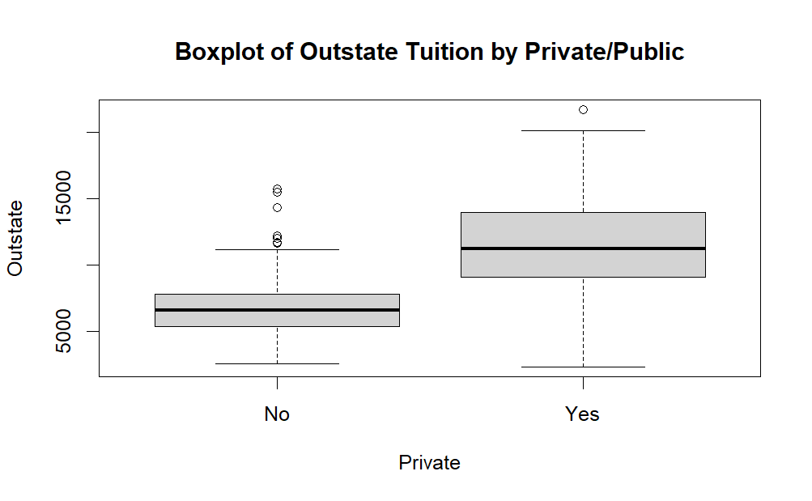

```r
attach(college) #makes variables from college available by name.
Private <- as.factor(Private) #the Private column will be treated as a categorical variable with two levels: "Yes and "No"
plot(Outstate ~ Private, #Plots outsate as a function of Private
     xlab = "Private",
     ylab= "Outstate",
     main = "Boxplot of Outstate Tuition by Private/Public")
```

iv.

```r
summary(college) #produces a numerical summary of the variables in the data set
```

```
   Private
 Length:777
 Class :character
 Mode  :character



      Apps           Accept
 Min.   :   81   Min.   :   72
 1st Qu.:  776   1st Qu.:  604
 Median : 1558   Median : 1110
 Mean   : 3002   Mean   : 2019
 3rd Qu.: 3624   3rd Qu.: 2424
 Max.   :48094   Max.   :26330
     Enroll       Top10perc
 Min.   :  35   Min.   : 1.00
 1st Qu.: 242   1st Qu.:15.00
 Median : 434   Median :23.00
 Mean   : 780   Mean   :27.56
 3rd Qu.: 902   3rd Qu.:35.00
 Max.   :6392   Max.   :96.00
   Top25perc      F.Undergrad
 Min.   :  9.0   Min.   :  139
 1st Qu.: 41.0   1st Qu.:  992
 Median : 54.0   Median : 1707
 Mean   : 55.8   Mean   : 3700
 3rd Qu.: 69.0   3rd Qu.: 4005
 Max.   :100.0   Max.   :31643
  P.Undergrad
 Min.   :    1.0
 1st Qu.:   95.0
 Median :  353.0
 Mean   :  855.3
 3rd Qu.:  967.0
 Max.   :21836.0
    Outstate       Room.Board
 Min.   : 2340   Min.   :1780
 1st Qu.: 7320   1st Qu.:3597
 Median : 9990   Median :4200
 Mean   :10441   Mean   :4358
```

[output cut: 15 more lines]

```
 Max.   :103.00   Max.   :100.0
   S.F.Ratio      perc.alumni
 Min.   : 2.50   Min.   : 0.00
 1st Qu.:11.50   1st Qu.:13.00
 Median :13.60   Median :21.00
 Mean   :14.09   Mean   :22.74
 3rd Qu.:16.50   3rd Qu.:31.00
 Max.   :39.80   Max.   :64.00
     Expend        Grad.Rate
 Min.   : 3186   Min.   : 10.00
 1st Qu.: 6751   1st Qu.: 53.00
 Median : 8377   Median : 65.00
 Mean   : 9660   Mean   : 65.46
 3rd Qu.:10830   3rd Qu.: 78.00
 Max.   :56233   Max.   :118.00
```

v.

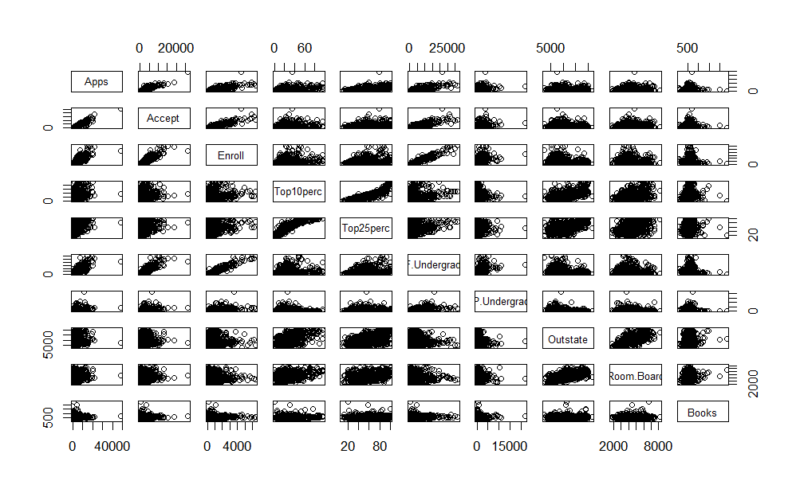

```r
pairs(college[, 2:11])
```

vi. Continue exploring the data, and provide a brief summary of what you discover

Exercise 9

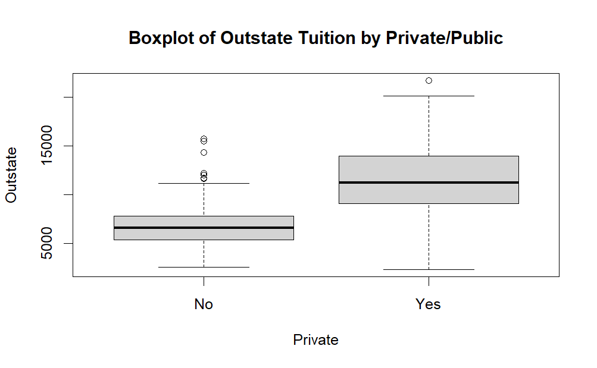

```r
attach(college) #makes variables from college available by name.
Private <- as.factor(Private) #the Private column will be treated as a categorical variable with two levels: "Yes and "No"
plot(Outstate ~ Private, #Plots outsate as a function of Private
     xlab = "Private",
     ylab= "Outstate",
     main = "Boxplot of Outstate Tuition by Private/Public")
```

```r
summary(auto)
```

```
      mpg          cylinders
 Min.   : 9.00   Min.   :3.000
 1st Qu.:17.50   1st Qu.:4.000
 Median :23.00   Median :4.000
 Mean   :23.52   Mean   :5.458
 3rd Qu.:29.00   3rd Qu.:8.000
 Max.   :46.60   Max.   :8.000
  displacement
 Min.   : 68.0
 1st Qu.:104.0
 Median :146.0
 Mean   :193.5
 3rd Qu.:262.0
 Max.   :455.0
  horsepower
 Length:397
 Class :character
 Mode  :character



     weight      acceleration
 Min.   :1613   Min.   : 8.00
 1st Qu.:2223   1st Qu.:13.80
 Median :2800   Median :15.50
 Mean   :2970   Mean   :15.56
 3rd Qu.:3609   3rd Qu.:17.10
 Max.   :5140   Max.   :24.80
      year           origin
 Min.   :70.00   Min.   :1.000
 1st Qu.:73.00   1st Qu.:1.000
 Median :76.00   Median :1.000
 Mean   :75.99   Mean   :1.574
 3rd Qu.:79.00   3rd Qu.:2.000
 Max.   :82.00   Max.   :3.000
     name
 Length:397
 Class :character
 Mode  :character
```

```r
str(auto)
```

```
'data.frame':   397 obs. of  9 variables:
 $ mpg         : num  18 15 18 16 17 15 14 14 14 15 ...
 $ cylinders   : int  8 8 8 8 8 8 8 8 8 8 ...
 $ displacement: num  307 350 318 304 302 429 454 440 455 390 ...
 $ horsepower  : chr  "130" "165" "150" "150" ...
 $ weight      : int  3504 3693 3436 3433 3449 4341 4354 4312 4425 3850 ...
 $ acceleration: num  12 11.5 11 12 10.5 10 9 8.5 10 8.5 ...
 $ year        : int  70 70 70 70 70 70 70 70 70 70 ...
 $ origin      : int  1 1 1 1 1 1 1 1 1 1 ...
 $ name        : chr  "chevrolet chevelle malibu" "buick skylark 320" "plymouth satellite" "amc rebel sst" ...
```

Based on the outputs we can conclude that “miles per gallon”, “cylinders”, “displacement”, “weight”, and “acceleration” are all quantitative variables. While “name”, “horsepower”, “year”, and “origin” are qualitative variables.

```r
Elite <- rep("No", nrow(college)) #creates a vector of the same length as the college data set with the value "No"
Elite[college$Top10perc > 50] <- "Yes" #Check for rows where the percentage of top students is greater than 50%. For those rows, the value in the Elite vectors is changed to "Yes"
Elite <- as.factor(Elite)
college <- data.frame(college, Elite) #converts vector into a factor, such that R will treate it as a categoricla grouping variable with two levels: "NO" and "Yes"
summary(Elite)
```

```
 No Yes
699  78
```

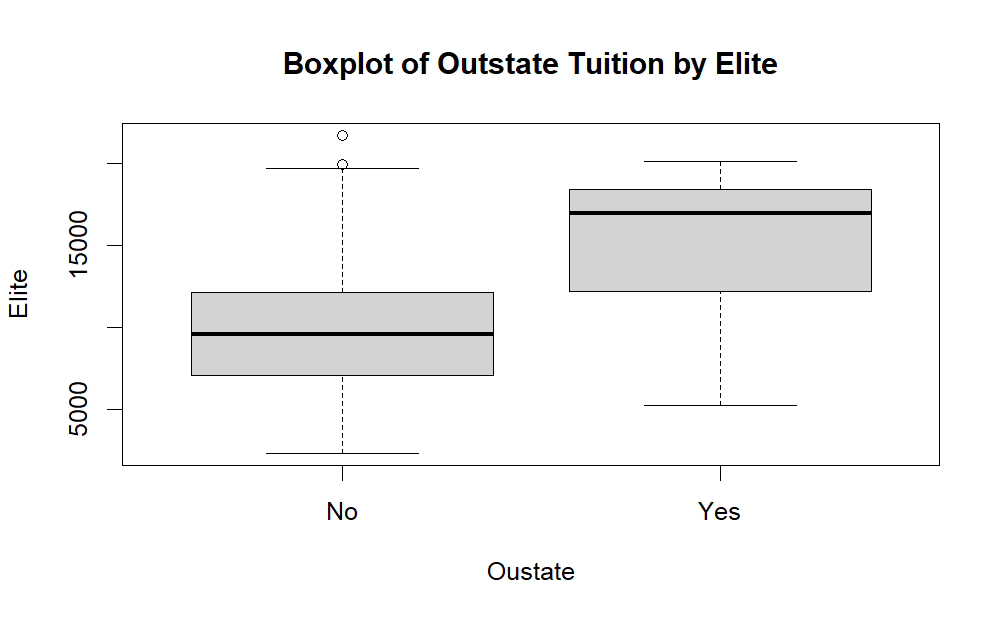

```r
attach(college)
plot(Outstate ~ Elite,
     xlab = "Oustate",
     ylab = "Elite",
     main = "Boxplot of Outstate Tuition by Elite")
```

```r
mean(auto$mpg)
```

```
[1] 23.51587
```

```r
sd(auto$mpg)
```

```
[1] 7.825804
```

```r
mean(auto$cylinders)
```

```
[1] 5.458438
```

```r
sd(auto$cylinders)
```

```
[1] 1.701577
```

```r
mean(auto$displacement)
```

```
[1] 193.5327
```

```r
sd(auto$displacement)
```

```
[1] 104.3796
```

```r
mean(auto$weight)
```

```
[1] 2970.262
```

```r
sd(auto$weight)
```

```
[1] 847.9041
```

```r
mean(auto$acceleration)
```

```
[1] 15.55567
```

```r
sd(auto$acceleration)
```

```
[1] 2.749995
```

```r
auto_sub <- auto[-(10:85), ]
range(auto_sub$mpg)
```

```
[1] 11.0 46.6
```

```r
mean(auto_sub$mpg)
```

```
[1] 24.43863
```

```r
sd(auto_sub$mpg)
```

```
[1] 7.908184
```

```r
range(auto_sub$cylinders)
```

```
[1] 3 8
```

```r
mean(auto_sub$cylinders)
```

```
[1] 5.370717
```

```r
sd(auto_sub$cylinders)
```

```
[1] 1.653486
```

```r
range(auto_sub$displacement)
```

```
[1]  68 455
```

```r
mean(auto_sub$displacement)
```

```
[1] 187.0498
```

```r
sd(auto_sub$displacement)
```

```
[1] 99.63539
```

```r
range(auto_sub$weight)
```

```
[1] 1649 4997
```

```r
mean(auto_sub$weight)
```

```
[1] 2933.963
```

```r
sd(auto_sub$weight)
```

```
[1] 810.6429
```

```r
range(auto_sub$horsepower)
```

```
[1] "?"  "98"
```

```r
mean(auto_sub$horsepower)
```

```
[1] NA
```

```r
sd(auto_sub$horsepower)
```

```
[1] NA
```

```r
range(auto_sub$acceleration)
```

```
[1]  8.5 24.8
```

```r
mean(auto_sub$acceleration)
```

```
[1] 15.72305
```

```r
sd(auto_sub$acceleration)
```

```
[1] 2.680514
```

```r
range(auto_sub$year)
```

```
[1] 70 82
```

```r
mean(auto_sub$year)
```

```
[1] 77.15265
```

```r
sd(auto_sub$year)
```

```
[1] 3.11123
```

```r
range(auto_sub$origin)
```

```
[1] 1 3
```

```r
mean(auto_sub$origin)
```

```
[1] 1.598131
```

```r
sd(auto_sub$origin)
```

```
[1] 0.8161627
```

```r
range(auto_sub$name)
```

[output not shown]

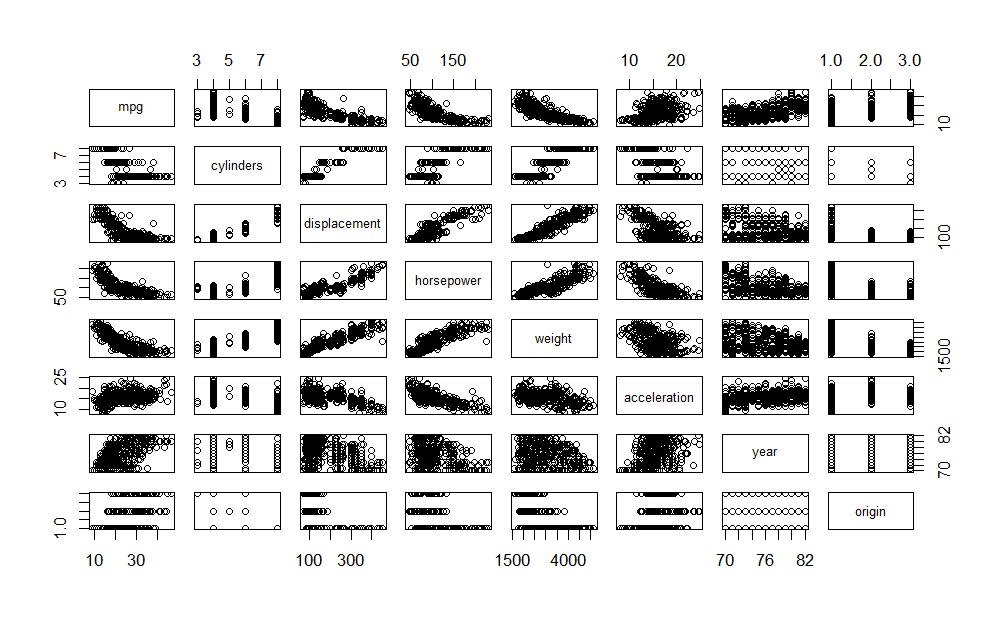

```r
auto$horsepower <- as.numeric(auto$horsepower)
pairs(auto[,1:8])
```

“miles per gallon” seems to have an inverse relationship with “displacement”, “horsepower”, and “weight”. However, it seems to have a converse relationship with “acceleration” and “year”.

“displacement” has an inverse relationship with “acceleration”, but a converse relationship with “horsepower” and “weight”.

“horsepower” has an inverse relationship with “acceleration”, but a converse relationship with “weight”.

“acceleration” and “weight” seem to have somewhat of an inverse relationship.

6. Yes. The plotting suggests that “displacement”, “horsepower”, “weight”, “acceleration”, and “year” could be useful when prediction gas mileage. Larger engines with higher horsepower have lower gas mileage as they tend to consumer fuel. Heavier cars also tend to have lower fuel efficiency. Newer cars might have improvements in fuel efficiency.